# FatherSonDataset

Dooratharsini Paskaran

2022-06-21

# Exploratory Data Analysis

- This is an R Markdown presentation created as a part of Coursera DataScience Specialization : Developing Data Products Course.
- Selected father son Data set from “UsingR” Package.
- The dataset contains height of 1078 fathers and their corresponding sons in inches.
- A data set contains 1078 observations on following 2 variables.

fheight - Father’s height in inches

sheight - Son’s height in inches

```
## 'data.frame':    1078 obs. of  2 variables:
##  $ fheight: num  65 63.3 65 65.8 61.1 ...
##  $ sheight: num  59.8 63.2 63.3 62.8 64.3 ...
```

```
##    fheight  sheight
## 1 65.04851 59.77827
## 2 63.25094 63.21404
## 3 64.95532 63.34242
## 4 65.75250 62.79238
## 5 61.13723 64.28113
## 6 63.02254 64.24221
```

- Few lines from data set

# Liner Model

- There seems to be an association between heights of fathers and those of sons.
- As you can see, as the height of father increases, those of son also increase. The strength of the association is calculated through correlation.

```r
cor(father.son)
```

```
##           fheight   sheight
## fheight 1.0000000 0.5013383
## sheight 0.5013383 1.0000000
```

- Analysis will establish a linear relation between height of father and son.
- Through a linear regression model, the height of son is predicted by height of father’s.

# Building linear model and Prediction

### Building Model

```r
summary(fit)
```

```
##
## Call:
## lm(formula = father.son$sheight ~ father.son$fheight)
##
## Residuals:
##     Min      1Q  Median      3Q     Max
## -8.8772 -1.5144 -0.0079  1.6285  8.9685
##
## Coefficients:
##                    Estimate Std. Error t value Pr(>|t|)
## (Intercept)        33.88660    1.83235   18.49   <2e-16 ***
## father.son$fheight  0.51409    0.02705   19.01   <2e-16 ***
## ---
## Signif. codes:  0 '***' 0.001 '**' 0.01 '*' 0.05 '.' 0.1 ' ' 1
##
## Residual standard error: 2.437 on 1076 degrees of freedom
## Multiple R-squared:  0.2513, Adjusted R-squared:  0.2506
## F-statistic: 361.2 on 1 and 1076 DF,  p-value: < 2.2e-16
```

### Prediction

- Linear relationship is established between height of father and son.
- Using the equation, height of the sons can be predicted by the height of their fathers.

# Plot

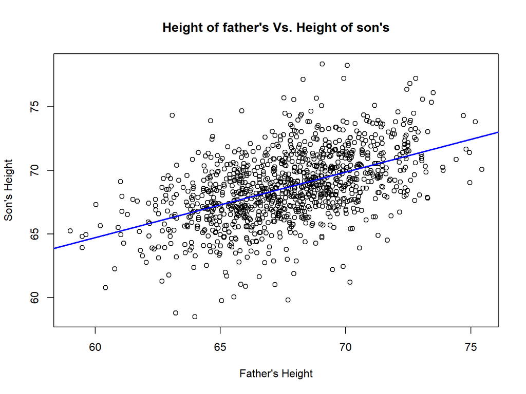

Height of the fathers and sons are associated positively with each other. As the height of father increases,those of sons also increase.